# Introdução à economia

Aula 07 - Desigualdade, fatores, salários e desemprego

Prof. Roberto de Freitas Neder

Instituto Federal de Brasília (IFB)

## Aula 07: roteiro

**Trabalho, renda e desigualdade** | IFB | Mankiw, capítulos 20, 18, 19 e 28

- Panorama da aula
- Desigualdade e pobreza
- Curva de Lorenz e Gini
- Justiça distributiva e proteção social
- Mercados de fatores de produção
- Produtividade e equilíbrio do trabalho
- Diferenças salariais e educação
- Discriminação e evidências
- Ocupação, desocupação e indicadores
- Causas do desemprego e instituições
- Síntese dos conceitos
- Revisão de verdadeiro ou falso

Navegue com as setas ou clique nos tópicos. No último slide, abra o gabarito para conferir as respostas.

## 01 - Quatro perguntas para compreender a economia

A produção de uma economia gera rendimentos, mas seus resultados **não se distribuem igualmente**.

1. Como medir **desigualdade e pobreza**?
2. Por que empresas demandam **trabalho, terra e capital**?
3. Por que trabalhadores recebem **salários diferentes**?
4. Como interpretar a **desocupação** e suas causas?

A aula conecta distribuição de renda, funcionamento dos mercados de fatores e situação do mercado de trabalho. O objetivo é interpretar conceitos, não realizar cálculos.

Voltar ao menu

## 02 - Desigualdade não é sinônimo de pobreza

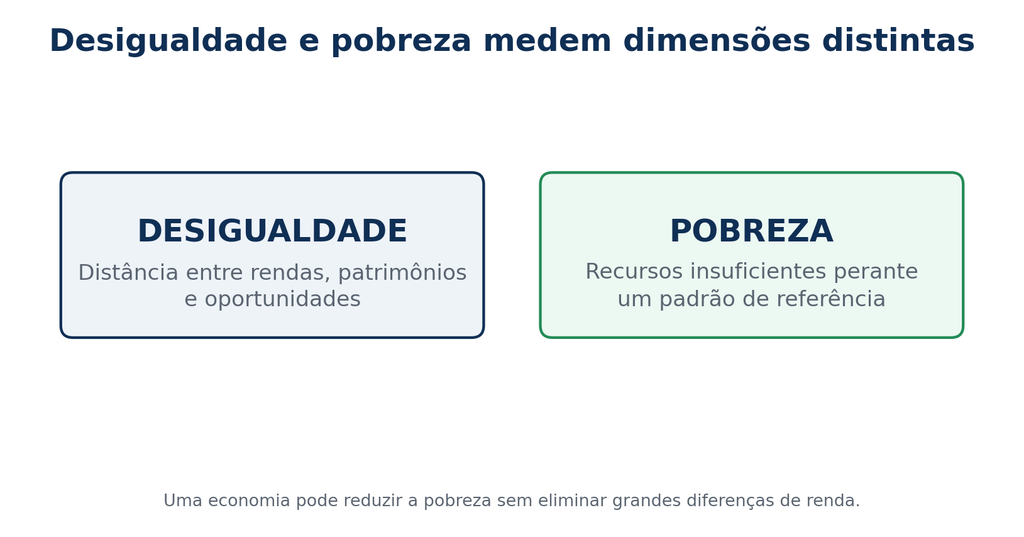

Desigualdade e pobreza são conceitos diferentes.

- **Desigualdade:** diferenças de renda, patrimônio ou oportunidades entre pessoas.
- **Pobreza:** insuficiência de recursos diante de uma linha ou padrão estabelecido.
- A renda média pode crescer sem reduzir proporcionalmente as desigualdades.

É possível reduzir a pobreza e continuar com elevada concentração de renda.

Voltar ao menu

## 03 - Quintis e curva de Lorenz

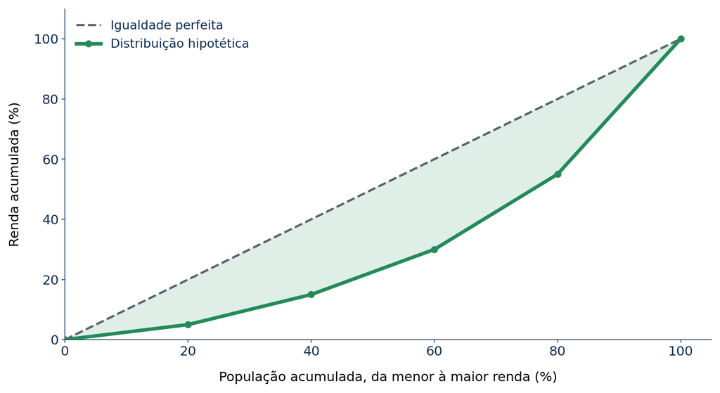

Curva de Lorenz com quintis e distribuição de renda hipotética.

- **Quintis:** cinco grupos com 20% da população em cada um, ordenados por renda.
- **Curva de Lorenz:** mostra a participação acumulada da renda.
- Quanto maior o afastamento da diagonal, maior a desigualdade da distribuição ilustrada.

Voltar ao menu

## 04 - Como interpretar o índice de Gini?

- O **índice de Gini** resume a concentração de renda representada pela curva de Lorenz.
- Na apresentação usual, varia de **0** (igualdade perfeita) a **1** (concentração máxima limite).
- Um Gini maior indica **mais desigualdade**, mas não informa o nível médio de renda.
- Dois países com Gini semelhante podem ter níveis de pobreza muito diferentes.

**Cuidado:** o Gini é uma medida sintética. Não descreve toda a distribuição, nem substitui informações sobre pobreza e mobilidade.

Voltar ao menu

## 05 - Pobreza: linha, incidência e profundidade

- A **linha de pobreza** define um patamar de referência para classificar insuficiência de renda.
- **Incidência:** proporção de pessoas abaixo da linha.
- **Profundidade:** considera o quanto a renda dos pobres fica abaixo da linha.
- Linhas **absolutas** procuram representar um padrão material; linhas **relativas** dependem da distribuição de renda da sociedade.

Uma política pode reduzir a profundidade da pobreza antes de reduzir o número de pessoas classificadas como pobres.

Voltar ao menu

## 06 - Renda anual, mobilidade e ciclo de vida

- A renda muda com a idade, a experiência, o desemprego e eventos temporários.
- **Renda transitória:** oscilações ocasionais, como um bônus ou a perda temporária do trabalho.
- **Mobilidade econômica:** mudança de posição na distribuição ao longo da vida ou entre gerações.
- Renda monetária não capta integralmente patrimônio, serviços públicos e condições de vida.

Uma fotografia da renda em um único ano não revela toda a trajetória econômica das famílias.

Voltar ao menu

## 07 - Justiça distributiva: três abordagens

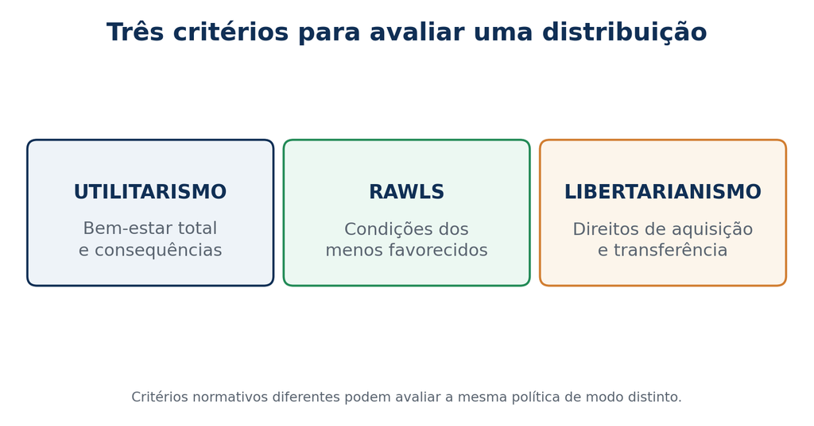

Três critérios normativos de avaliação distributiva.

- **Utilitarismo:** avalia as consequências para o bem-estar agregado.
- **Rawls:** enfatiza regras justificáveis sob o véu da ignorância e a situação dos menos favorecidos.
- **Libertarianismo:** destaca direitos e legitimidade das aquisições e transferências.

Medir desigualdade é uma tarefa **positiva**; decidir qual distribuição é justa envolve critérios **normativos**.

Voltar ao menu

## 08 - Combate à pobreza: proteção e incentivos

- **Transferências monetárias** permitem maior liberdade de escolha às famílias.
- **Serviços públicos** podem assegurar acesso a saúde, educação e outros bens essenciais.
- Políticas devem considerar cobertura, custos, focalização e capacidade de implementação.
- Se o benefício desaparece integralmente com qualquer aumento da renda do trabalho, pode haver **desestímulo à renda adicional**.

O desafio é combinar proteção social com oportunidades, sem confundir efeitos desejados com resultados empiricamente demonstrados.

Voltar ao menu

## 09 - Os mercados de fatores de produção

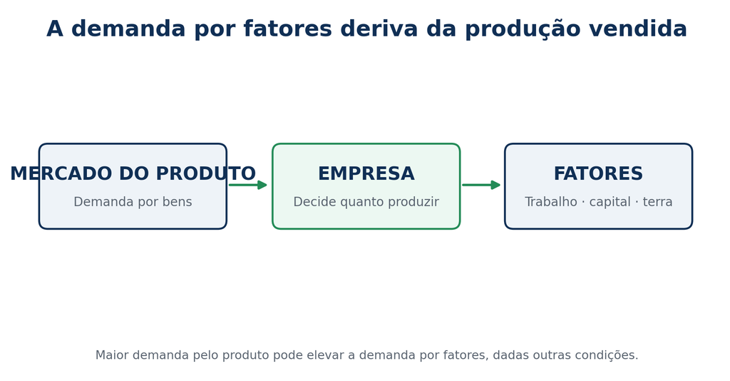

A demanda por fatores deriva das decisões de produção.

- Produzir bens e serviços exige **trabalho, capital físico e terra**.
- Famílias e proprietários ofertam fatores; empresas demandam seus serviços.
- A demanda é **derivada**: depende do valor do produto que os fatores ajudam a gerar.

Voltar ao menu

## 10 - Produto marginal e rendimentos decrescentes

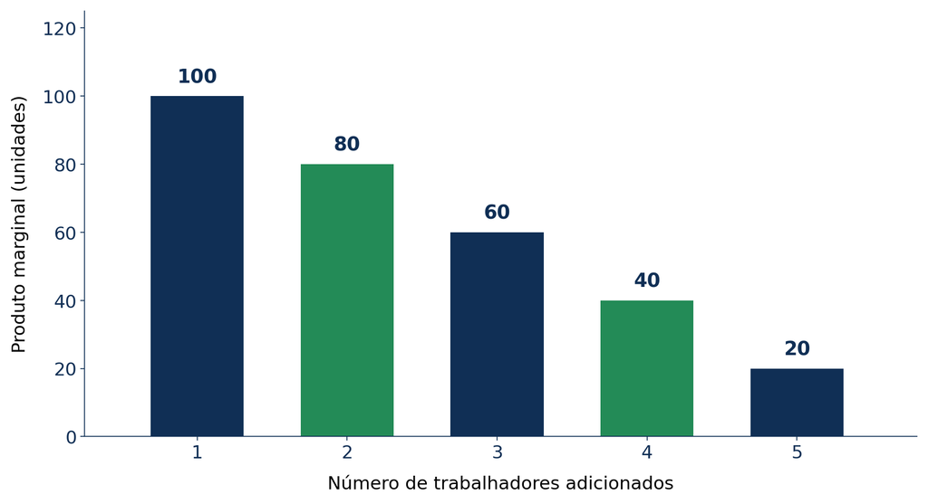

Exemplo hipotético de produto marginal decrescente do trabalho.

- **Produto marginal:** produção adicional obtida ao empregar mais uma unidade de fator.
- Com outros recursos fixos, acréscimos de trabalho podem gerar **ganhos progressivamente menores**.
- Produto marginal menor não significa, necessariamente, que o **produto total caiu**.

Voltar ao menu

## 11 - Por que a empresa contrata mais um trabalhador?

A decisão depende do benefício e do custo de contratar.

- **Benefício adicional:** valor do produto marginal do trabalho.
- **Custo adicional:** remuneração e outros custos relevantes de contratação.
- No modelo competitivo simples, a empresa amplia o emprego enquanto o **benefício adicional cobre o custo**.
- Se o salário aumenta, sem mudança nas demais condições, algumas contratações tornam-se menos atrativas.

A demanda por trabalho está associada à produtividade marginal **e** ao preço do produto, não apenas ao número de candidatos disponíveis.

Voltar ao menu

## 12 - O que desloca a demanda por trabalho?

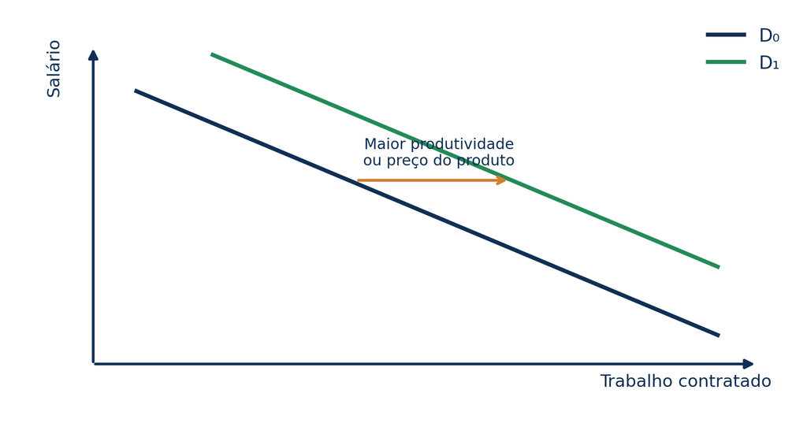

Deslocamento ilustrativo da demanda por trabalho.

- Maior **demanda pelo produto final** pode tornar a contratação mais rentável.
- **Tecnologia complementar** pode ampliar o produto marginal de determinados trabalhadores.
- Tecnologias que **substituem tarefas** podem reduzir a procura por ocupações específicas.

Um deslocamento da curva não é a mesma coisa que uma mudança da quantidade demandada ao longo dela.

Voltar ao menu

## 13 - A oferta de trabalho e o custo de oportunidade

- Trabalhar mais horas significa abrir mão de tempo para lazer, estudo, cuidado ou outras atividades.
- **Efeito substituição:** salário maior torna mais caro abrir mão de uma hora de trabalho remunerado.
- **Efeito renda:** salário maior pode permitir alcançar renda desejada com menos horas.
- A reação da oferta depende da predominância dos dois efeitos, além de restrições concretas.

A oferta de trabalho não é uma decisão inteiramente livre quando existem restrições de cuidado, transporte, saúde e disponibilidade de vagas.

Voltar ao menu

## 14 - Equilíbrio do mercado de trabalho

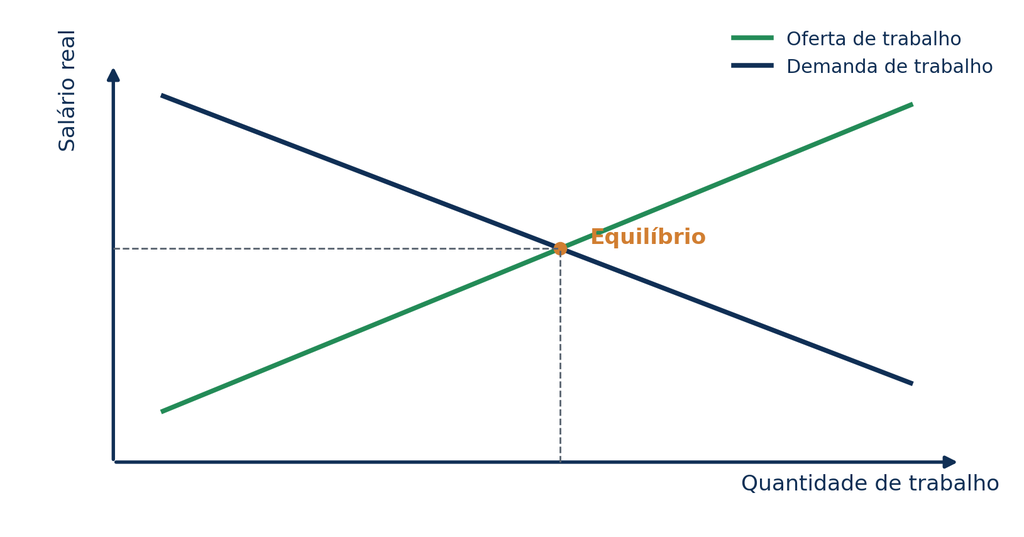

Oferta e demanda de trabalho em um mercado competitivo ilustrativo.

- O **salário real** e a quantidade de trabalho contratada resultam do encontro entre oferta e demanda, na referência competitiva.
- Maior demanda pode elevar salários e emprego; maior oferta tende a ampliar emprego e pressionar salários.
- O gráfico é um **modelo**, não uma descrição completa de todo o mercado brasileiro.

Voltar ao menu

## 15 - Terra, capital e complementaridade

- **Capital físico:** máquinas, instalações, equipamentos e outros bens usados na produção.
- **Terra e recursos naturais:** fatores cuja disponibilidade pode ser limitada.
- Empresas demandam fatores conforme sua contribuição para o valor produzido.
- Mais máquinas complementares ao trabalho podem ampliar a produtividade e a demanda por trabalhadores.

Preço de compra de um ativo e preço de aluguel de seus serviços são conceitos diferentes.

Voltar ao menu

## 16 - Os limites da concorrência: monopsônio

- **Monopsônio:** situação em que um empregador, ou poucos compradores, possuem poder na contratação de trabalho.
- Trabalhadores com pouca mobilidade ou poucas alternativas enfrentam menor poder de negociação.
- Um empregador com poder de compra pode pagar salários e contratar quantidades diferentes das previstas no modelo competitivo.
- Por isso, os efeitos de políticas salariais dependem da **estrutura do mercado**.

A condição competitiva é uma referência analítica. Não é uma lei que se aplica identicamente a todos os empregos.

Voltar ao menu

## 17 - Por que os salários são diferentes?

- **Diferenciais compensatórios:** remunerações associadas a riscos, horários e condições não monetárias dos postos.
- **Experiência, qualificação e habilidades** também podem afetar a produtividade e o salário.
- Características de empresas, regiões, ocupações e instituições importam.
- Uma diferença salarial observada não tem, necessariamente, uma única causa.

Comparar rendimentos exige atenção a horas trabalhadas, ocupações e às oportunidades de acesso a cada posto.

Voltar ao menu

## 18 - Capital humano e rendimentos

- Educação, treinamento, saúde e experiência podem elevar a **capacidade produtiva**.
- Formação envolve custos diretos e o custo de oportunidade do tempo empregado no estudo.
- O retorno esperado não é idêntico para todas as pessoas e ocupações.
- Políticas educacionais podem ampliar oportunidades, mas a relação entre escolaridade e salários depende do contexto.

O conceito de capital humano trata do conhecimento e das competências incorporadas às pessoas, não de sua condição como propriedade de alguém.

Voltar ao menu

## 19 - A educação também pode funcionar como sinal

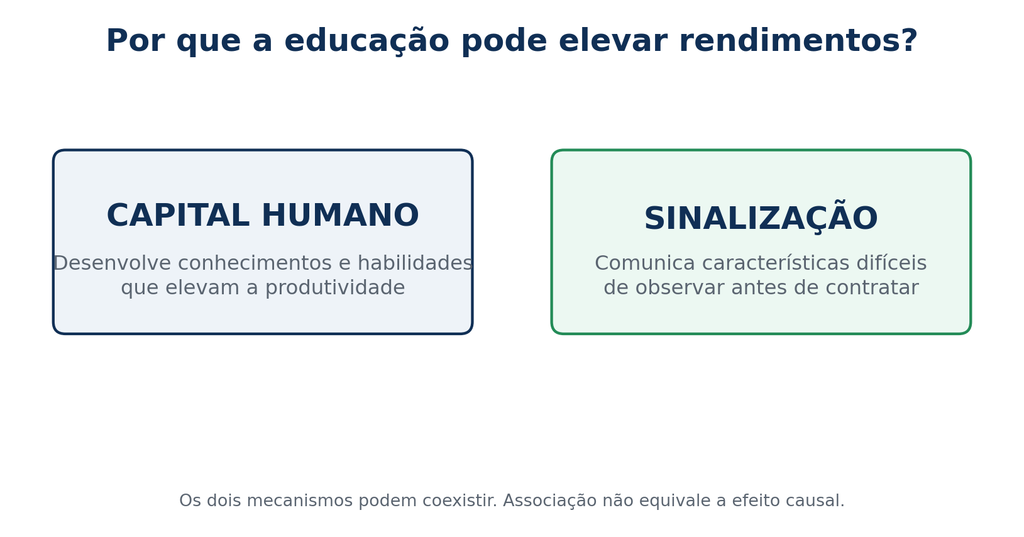

Dois mecanismos econômicos da educação: produtividade e sinalização.

- **Capital humano:** o curso ensina algo que melhora a produção.
- **Sinalização:** a certificação comunica atributos que o empregador não observa diretamente.
- Os mecanismos podem coexistir; uma correlação entre escolaridade e salário não prova isoladamente nenhum deles.

Voltar ao menu

## 20 - Tecnologia, habilidades e superestrelas

- Mudanças tecnológicas alteram a demanda por tarefas e qualificações.
- Algumas tecnologias **complementam** habilidades; outras substituem atividades específicas.
- Em mercados com grande alcance e baixo custo de reprodução, poucas pessoas podem atender milhões de consumidores.
- Isso ajuda a compreender o fenômeno das **superestrelas** e rendimentos muito elevados em certos mercados.

A tecnologia não afeta todos os trabalhadores da mesma maneira. Seus efeitos dependem de ocupações e instituições.

Voltar ao menu

## 21 - Diferenças salariais e discriminação

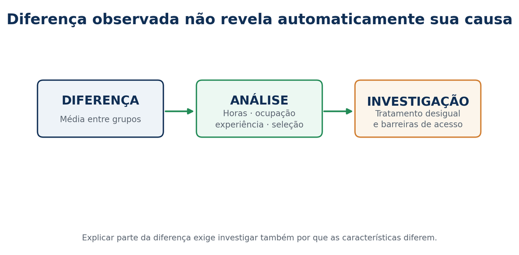

Esquema para interpretar diferenças de rendimentos entre grupos.

- **Discriminação:** tratamento desigual por características sem justificativa pertinente à função.
- Pode aparecer em contratação, salários, promoção ou acesso a treinamento.
- **Diferença bruta** entre médias não mede automaticamente discriminação.
- Uma análise precisa investigar composição, acesso às oportunidades e comportamento dos empregadores.

Voltar ao menu

## 22 - Evidências e políticas contra a discriminação

- Comparações por ocupação, experiência e jornada ajudam a compreender diferenças observadas.
- **Experimentos com currículos equivalentes** podem identificar tratamento desigual em processos seletivos.
- A ausência de uma diferença salarial ajustada não prova ausência de barreiras anteriores ao emprego.
- Fiscalização, transparência e seleção estruturada podem reduzir práticas discriminatórias.

Explicar estatisticamente uma diferença não significa justificá-la do ponto de vista ético ou jurídico.

Voltar ao menu

## 23 - Ocupação, desocupação e inatividade

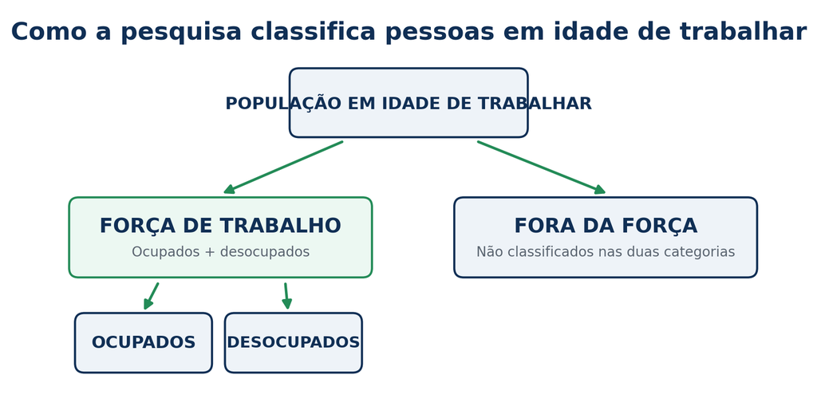

Classificação da população segundo a posição no mercado de trabalho.

- **Ocupado:** realizou trabalho ou atende às condições de ocupação da pesquisa.
- **Desocupado:** não está ocupado, procurou trabalho e está disponível, conforme as regras da pesquisa.
- **Fora da força de trabalho:** não se enquadra nessas duas categorias.

Estudar, cuidar da família ou estar aposentado não determina isoladamente a classificação de uma pessoa.

Voltar ao menu

## 24 - Três indicadores que precisam ser lidos juntos

| Indicador | Pergunta respondida |
| --- | --- |
| **Taxa de desocupação** | Qual fração da força de trabalho está desocupada? |
| **Taxa de participação** | Qual fração da população em idade de trabalhar integra a força de trabalho? |
| **Nível de ocupação** | Qual fração da população em idade de trabalhar está ocupada? |

- No Brasil, a **PNAD Contínua** é uma referência central para essas medidas.
- Os indicadores têm **denominadores diferentes**; por isso não contam a mesma história.

Voltar ao menu

## 25 - Uma queda da desocupação pode enganar

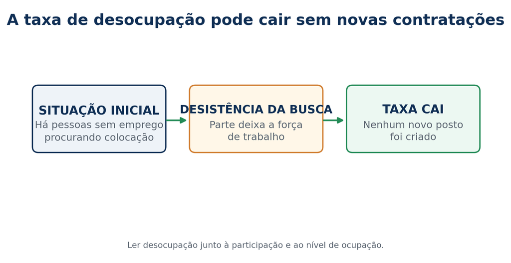

O desemprego medido pode cair sem contratação quando pessoas deixam de buscar emprego.

- Quando uma pessoa deixa de procurar ocupação, pode passar de **desocupada** para **fora da força**.
- A taxa de desocupação pode cair **sem criação de novos empregos**.
- Por isso, é preciso observar simultaneamente participação, ocupação e condições de trabalho.

Voltar ao menu

## 26 - Informalidade não é desocupação

- Uma pessoa com **trabalho informal** pode ser classificada como ocupada.
- Quem trabalha menos horas do que gostaria pode estar em **subocupação por insuficiência de horas**, conforme critérios específicos.
- Indicadores ampliados de **subutilização da força de trabalho** captam situações além da desocupação aberta.
- Registros de vínculos e pesquisas domiciliares podem contar unidades diferentes: **postos** versus **pessoas**.

Uma boa análise do mercado de trabalho não se limita à taxa de desocupação.

Voltar ao menu

## 27 - Desemprego friccional, estrutural e cíclico

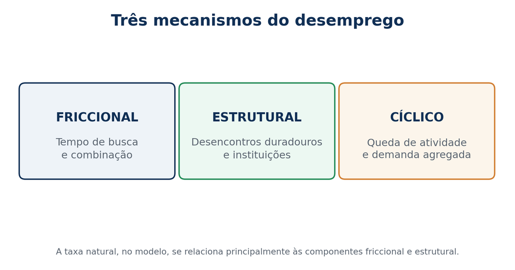

Três mecanismos do desemprego.

- **Friccional:** tempo necessário para encontrar uma combinação entre candidato e vaga.
- **Estrutural:** desencontros duradouros, custos e instituições que impedem ajustes simples.
- **Cíclico:** quedas da atividade econômica e da demanda por trabalhadores.

A **taxa natural** é uma referência de longo prazo do modelo, não um mínimo inevitável, imutável ou desejável.

Voltar ao menu

## 28 - Busca, informação e qualificação

- Empregadores e candidatos possuem informações incompletas sobre vagas e competências.
- Distâncias geográficas, transporte e falta de qualificação dificultam o encontro.
- **Intermediação** de emprego aproxima vagas e candidatos.
- **Formação e requalificação** podem reduzir desencontros e facilitar mudanças setoriais.
- O **seguro-desemprego** protege renda durante a busca, com possíveis efeitos sobre a duração e a qualidade da recolocação.

Voltar ao menu

## 29 - Salário mínimo e negociação coletiva

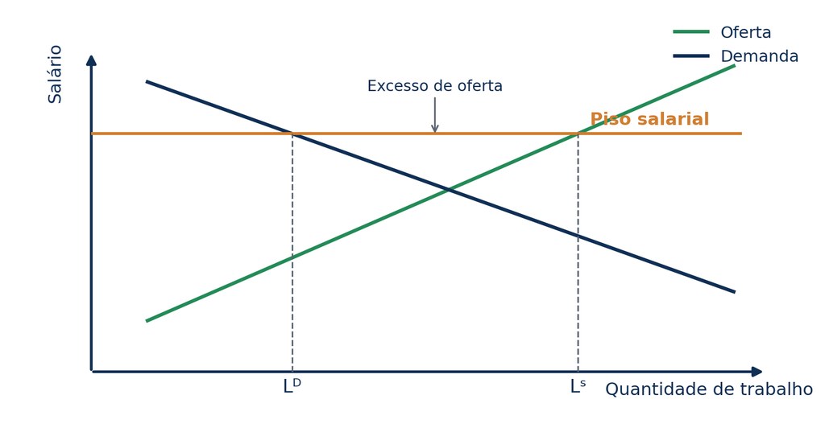

Efeito ilustrativo de um piso acima do equilíbrio no modelo competitivo.

- Na referência **competitiva**, um piso vinculante tende a gerar excesso de oferta de trabalho.
- Em um mercado com **poder de monopsônio**, um piso adequadamente situado pode elevar salário e emprego.
- **Sindicatos** podem negociar remunerações e condições e contrabalançar poder empresarial.

Os efeitos concretos dependem da estrutura do mercado, do nível do piso, da cobertura e das respostas das empresas.

Voltar ao menu

## 30 - Salários de eficiência e desemprego

Uma empresa pode decidir pagar **mais do que o salário que equilibraria oferta e demanda**.

- **Saúde e nutrição:** melhores condições podem aumentar capacidade produtiva.
- **Rotatividade:** salários maiores podem reduzir saídas e gastos com treinamento.
- **Seleção:** uma boa remuneração pode atrair candidatos mais qualificados.
- **Esforço:** a perda de um bom emprego torna a demissão mais custosa ao trabalhador.

A teoria mostra por que pode persistir desemprego mesmo sem piso legal ou sindicato responsável por salários acima do equilíbrio.

Voltar ao menu

## 31 - Síntese: como os conceitos se conectam?

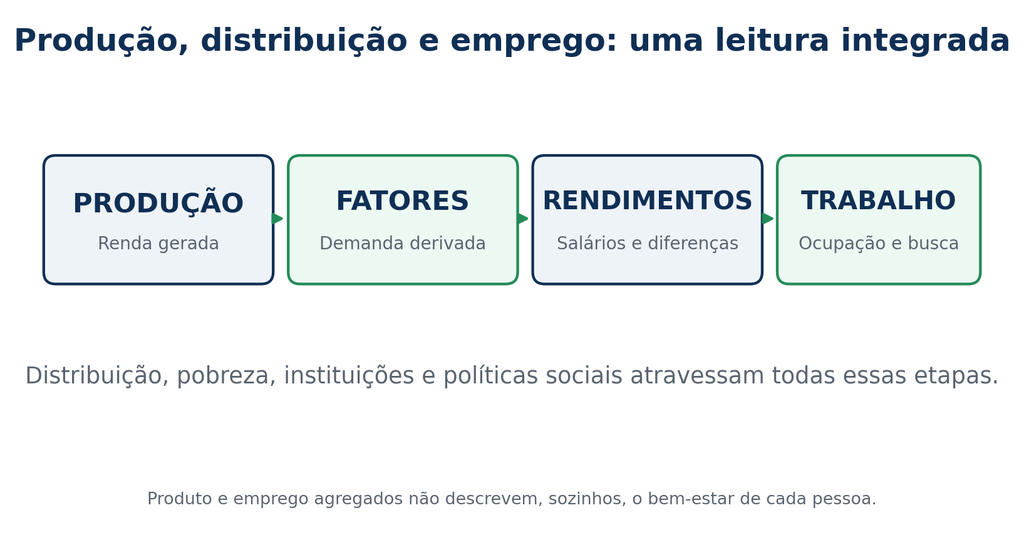

Relação entre produção, demanda por fatores, salários e emprego.

1. Produção gera renda, mas **não determina sua distribuição**.
2. Empresas demandam fatores por sua **contribuição à produção**.
3. Salários dependem de **produtividade, condições, informação e instituições**.
4. Desocupação e pobreza exigem **medidas distintas** e políticas adequadas a seus mecanismos.

Voltar ao menu

## 32 - Revisão conceitual: verdadeiro ou falso

**Julgue os itens antes de abrir o gabarito. Não há cálculos.**

1. A redução da pobreza elimina necessariamente a desigualdade de renda.
2. Um índice de Gini mais alto indica maior concentração na medida usual.
3. Empresas demandam trabalho independentemente da procura por seus produtos.
4. Um salário mais alto sempre aumenta a quantidade de trabalho ofertada por uma pessoa.
5. Escolaridade pode influenciar rendimentos por produtividade e por sinalização.
6. Toda diferença salarial média entre grupos é uma medida exata de discriminação.
7. A taxa de desocupação pode cair sem que novos empregos sejam criados.
8. No monopsônio, um salário mínimo apropriado pode elevar emprego e remuneração.

**Abrir gabarito comentado**

**1. F:** pobreza e desigualdade são dimensões diferentes.  
**2. V:** maior Gini representa maior concentração na convenção usual.  
**3. F:** demanda por fatores é derivada da produção esperada.  
**4. F:** efeitos renda e substituição podem atuar em direções opostas.  
**5. V:** capital humano e sinalização podem coexistir.  
**6. F:** diferenças brutas exigem investigação de composição e tratamento.  
**7. V:** a saída da força de trabalho pode reduzir a taxa medida.  
**8. V:** depende da estrutura de mercado e do valor do piso.

Voltar ao menu